# Delayed Flights Exploration

## Preliminary Wrangling

The data that we will be exploring in this notebook is originally from [The U.S. Department of Transportation's (DOT) Bureau of Transportation Statistics (BTS)](https://www.transtats.bts.gov/OT_Delay/OT_DelayCause1.asp) that tracks performance of domestic US flights operated by large air transit companies. There consists of a number of on-time, delayed, cancelled etc. flights that were recorded for the 2008 year.

```python
# import all packages and set plots to be embedded inline
import numpy as np
import pandas as pd
import matplotlib.pyplot as plt
import seaborn as sb

%matplotlib inline
```

```python
# Read in data file

df = pd.read_csv('DelayedFlights.csv')
```

```python
# General high level information

print(df.shape)
print(df.describe())
print(df.dtypes)
df.head()
```

```
(1936758, 30)
         Unnamed: 0       Year         Month    DayofMonth     DayOfWeek  \
count  1.936758e+06  1936758.0  1.936758e+06  1.936758e+06  1.936758e+06
mean   3.341651e+06     2008.0  6.111106e+00  1.575347e+01  3.984827e+00
std    2.066065e+06        0.0  3.482546e+00  8.776272e+00  1.995966e+00
min    0.000000e+00     2008.0  1.000000e+00  1.000000e+00  1.000000e+00
25%    1.517452e+06     2008.0  3.000000e+00  8.000000e+00  2.000000e+00
50%    3.242558e+06     2008.0  6.000000e+00  1.600000e+01  4.000000e+00
75%    4.972467e+06     2008.0  9.000000e+00  2.300000e+01  6.000000e+00
max    7.009727e+06     2008.0  1.200000e+01  3.100000e+01  7.000000e+00

            DepTime    CRSDepTime       ArrTime    CRSArrTime     FlightNum  \
count  1.936758e+06  1.936758e+06  1.929648e+06  1.936758e+06  1.936758e+06
mean   1.518534e+03  1.467473e+03  1.610141e+03  1.634225e+03  2.184263e+03
std    4.504853e+02  4.247668e+02  5.481781e+02  4.646347e+02  1.944702e+03
min    1.000000e+00  0.000000e+00  1.000000e+00  0.000000e+00  1.000000e+00
25%    1.203000e+03  1.135000e+03  1.316000e+03  1.325000e+03  6.100000e+02
50%    1.545000e+03  1.510000e+03  1.715000e+03  1.705000e+03  1.543000e+03
75%    1.900000e+03  1.815000e+03  2.030000e+03  2.014000e+03  3.422000e+03
max    2.400000e+03  2.359000e+03  2.400000e+03  2.400000e+03  9.742000e+03

       ActualElapsedTime  CRSElapsedTime       AirTime      ArrDelay  \
count       1.928371e+06    1.936560e+06  1.928371e+06  1.928371e+06
mean        1.333059e+02    1.343027e+02  1.082771e+02  4.219988e+01
std         7.206007e+01    7.134144e+01  6.864261e+01  5.678472e+01
min         1.400000e+01   -2.500000e+01  0.000000e+00 -1.090000e+02
25%         8.000000e+01    8.200000e+01  5.800000e+01  9.000000e+00
50%         1.160000e+02    1.160000e+02  9.000000e+01  2.400000e+01
75%         1.650000e+02    1.650000e+02  1.370000e+02  5.600000e+01
max         1.114000e+03    6.600000e+02  1.091000e+03  2.461000e+03

           DepDelay      Distance        TaxiIn       TaxiOut     Cancelled  \
count  1.936758e+06  1.936758e+06  1.929648e+06  1.936303e+06  1.936758e+06
mean   4.318518e+01  7.656862e+02  6.812975e+00  1.823220e+01  3.268348e-04
std    5.340250e+01  5.744797e+02  5.273595e+00  1.433853e+01  1.807562e-02
min    6.000000e+00  1.100000e+01  0.000000e+00  0.000000e+00  0.000000e+00
25%    1.200000e+01  3.380000e+02  4.000000e+00  1.000000e+01  0.000000e+00
50%    2.400000e+01  6.060000e+02  6.000000e+00  1.400000e+01  0.000000e+00
75%    5.300000e+01  9.980000e+02  8.000000e+00  2.100000e+01  0.000000e+00
max    2.467000e+03  4.962000e+03  2.400000e+02  4.220000e+02  1.000000e+00
```

[output cut: 36 more lines]

```
DepDelay             float64
Origin                object
Dest                  object
Distance               int64
TaxiIn               float64
TaxiOut              float64
Cancelled              int64
CancellationCode      object
Diverted               int64
CarrierDelay         float64
WeatherDelay         float64
NASDelay             float64
SecurityDelay        float64
LateAircraftDelay    float64
dtype: object
```

|  | Unnamed: 0 | Year | Month | DayofMonth | DayOfWeek | DepTime | CRSDepTime | ArrTime | CRSArrTime | UniqueCarrier | FlightNum | TailNum | ActualElapsedTime | CRSElapsedTime | AirTime | ArrDelay | DepDelay | Origin | Dest | Distance | TaxiIn | TaxiOut | Cancelled | CancellationCode | Diverted | CarrierDelay | WeatherDelay | NASDelay | SecurityDelay | … |
| --- | --- | --- | --- | --- | --- | --- | --- | --- | --- | --- | --- | --- | --- | --- | --- | --- | --- | --- | --- | --- | --- | --- | --- | --- | --- | --- | --- | --- | --- | --- |
| 0 | 0 | 2008 | 1 | 3 | 4 | 2003.0 | 1955 | 2211.0 | 2225 | WN | 335 | N712SW | 128.0 | 150.0 | 116.0 | -14.0 | 8.0 | IAD | TPA | 810 | 4.0 | 8.0 | 0 | N | 0 | NaN | NaN | NaN | NaN | … |
| 1 | 1 | 2008 | 1 | 3 | 4 | 754.0 | 735 | 1002.0 | 1000 | WN | 3231 | N772SW | 128.0 | 145.0 | 113.0 | 2.0 | 19.0 | IAD | TPA | 810 | 5.0 | 10.0 | 0 | N | 0 | NaN | NaN | NaN | NaN | … |
| 2 | 2 | 2008 | 1 | 3 | 4 | 628.0 | 620 | 804.0 | 750 | WN | 448 | N428WN | 96.0 | 90.0 | 76.0 | 14.0 | 8.0 | IND | BWI | 515 | 3.0 | 17.0 | 0 | N | 0 | NaN | NaN | NaN | NaN | … |
| 3 | 4 | 2008 | 1 | 3 | 4 | 1829.0 | 1755 | 1959.0 | 1925 | WN | 3920 | N464WN | 90.0 | 90.0 | 77.0 | 34.0 | 34.0 | IND | BWI | 515 | 3.0 | 10.0 | 0 | N | 0 | 2.0 | 0.0 | 0.0 | 0.0 | … |
| 4 | 5 | 2008 | 1 | 3 | 4 | 1940.0 | 1915 | 2121.0 | 2110 | WN | 378 | N726SW | 101.0 | 115.0 | 87.0 | 11.0 | 25.0 | IND | JAX | 688 | 4.0 | 10.0 | 0 | N | 0 | NaN | NaN | NaN | NaN | … |

```python
pd.set_option('display.max_columns', 500) #to show hidden columns

df.head()
```

|  | Unnamed: 0 | Year | Month | DayofMonth | DayOfWeek | DepTime | CRSDepTime | ArrTime | CRSArrTime | UniqueCarrier | FlightNum | TailNum | ActualElapsedTime | CRSElapsedTime | AirTime | ArrDelay | DepDelay | Origin | Dest | Distance | TaxiIn | TaxiOut | Cancelled | CancellationCode | Diverted | CarrierDelay | WeatherDelay | NASDelay | SecurityDelay | … |
| --- | --- | --- | --- | --- | --- | --- | --- | --- | --- | --- | --- | --- | --- | --- | --- | --- | --- | --- | --- | --- | --- | --- | --- | --- | --- | --- | --- | --- | --- | --- |
| 0 | 0 | 2008 | 1 | 3 | 4 | 2003.0 | 1955 | 2211.0 | 2225 | WN | 335 | N712SW | 128.0 | 150.0 | 116.0 | -14.0 | 8.0 | IAD | TPA | 810 | 4.0 | 8.0 | 0 | N | 0 | NaN | NaN | NaN | NaN | … |
| 1 | 1 | 2008 | 1 | 3 | 4 | 754.0 | 735 | 1002.0 | 1000 | WN | 3231 | N772SW | 128.0 | 145.0 | 113.0 | 2.0 | 19.0 | IAD | TPA | 810 | 5.0 | 10.0 | 0 | N | 0 | NaN | NaN | NaN | NaN | … |
| 2 | 2 | 2008 | 1 | 3 | 4 | 628.0 | 620 | 804.0 | 750 | WN | 448 | N428WN | 96.0 | 90.0 | 76.0 | 14.0 | 8.0 | IND | BWI | 515 | 3.0 | 17.0 | 0 | N | 0 | NaN | NaN | NaN | NaN | … |
| 3 | 4 | 2008 | 1 | 3 | 4 | 1829.0 | 1755 | 1959.0 | 1925 | WN | 3920 | N464WN | 90.0 | 90.0 | 77.0 | 34.0 | 34.0 | IND | BWI | 515 | 3.0 | 10.0 | 0 | N | 0 | 2.0 | 0.0 | 0.0 | 0.0 | … |
| 4 | 5 | 2008 | 1 | 3 | 4 | 1940.0 | 1915 | 2121.0 | 2110 | WN | 378 | N726SW | 101.0 | 115.0 | 87.0 | 11.0 | 25.0 | IND | JAX | 688 | 4.0 | 10.0 | 0 | N | 0 | NaN | NaN | NaN | NaN | … |

### What is the structure of your dataset?

There are 1936758 rows and 30 columns in this dataset.

- Year: 2008
- Month: 1-12
- DayofMonth: 1-31
- DayOfWeek: 1 (Monday) - 7 (Sunday)
- DepTime: actual departure time (local, hhmm)
- CRSDepTime: scheduled departure time (local, hhmm)
- ArrTime: actual arrival time (local, hhmm)
- CRSArrTime: scheduled arrival time (local, hhmm)
- UniqueCarrier: unique carrier code
- FlightNum: flight number
- TailNum: plane tail number
- ActualElapsedTime: in minutes
- CRSElapsedTime: in minutes
- AirTime: in minutes
- ArrDelay: arrival delay, in minutes
- DepDelay: departure delay, in minutes
- Origin: origin IATA airport code
- Dest: destination IATA airport code
- Distance: in miles
- TaxiIn: taxi in time, in minutes
- TaxiOut: taxi out time in minutes
- Cancelled: was the flight cancelled?
- CancellationCode: reason for cancellation (A = carrier, B = weather, C = NAS, D = security)
- Diverted: 1 = yes, 0 = no
- CarrierDelay: in minutes
- WeatherDelay: in minutes
- NASDelay: in minutes
- SecurityDelay: in minutes
- LateAircraftDelay: in minutes

### What is/are the main feature(s) of interest in your dataset?

Out of the 30 columns, I would like to focus on the time columns (Month, Day, DepTime, ArrTime, etc.) and the Cancelled feature to see if flights were frequently cancelled and why.

### What features in the dataset do you think will help support your investigation into your feature(s) of interest?

I suspect Month, DayofMonth, DayOfWeek, DepTime, ArrTime, Cancelled and ArrDelay columns will be supportive for my investigation.

```python
flights = df.copy() #use copied dataset for wrangling and analysis
```

Before we get into our exploration, I would like to see if we can clean up the data set first. This will help us later with our analysis.

Assess:

- drop 'Unnamed', 'CRS' columns, 'Taxi in', 'Taxi out', Unique carrier', 'tail number'
- 'Year', 'Month', 'DayofMonth', 'DayOfWeek' can be datetime
- 'DepTime', 'ArrTime' can be datetime
- 'CancellationCode' can be categorical
- Delay columns need to be integers not floats
- Actual Elapsed time can be an integer, not a float (minutes)

```python
# Drop unwanted columns

# flights = flights.drop(['Unnamed: 0', 'CRSDepTime', 'CRSArrTime', 'TailNum', 'CRSElapsedTime', 'TaxiIn', 'TaxiOut'], axis = 1)

flights = flights.drop('Unnamed: 0', axis=1)
flights = flights.drop('CRSDepTime', axis=1)
flights = flights.drop('CRSArrTime', axis=1)
flights = flights.drop('TailNum', axis=1)
flights = flights.drop('TaxiIn', axis=1)
flights = flights.drop('TaxiOut', axis=1)
flights = flights.drop('CRSElapsedTime', axis=1)

# Year, Month, DayofMonth, DayofWeek, CancellationCode can all be categorical objects

flights[['Year', 'Month', 'DayofMonth', 'DayOfWeek', 'CancellationCode']] = flights[['Year', 'Month', 'DayofMonth', 'DayOfWeek', 'CancellationCode']].astype('category')

# DepTime', 'ArrTime' can be strings first

# flights[['DepTime', 'ArrTime']] = flights[['DepTime', 'ArrTime']].astype(str).str[:-2]

flights[['DepTime', 'ArrTime']] = flights[['DepTime', 'ArrTime']].astype(str)

# Test
flights.dtypes
```

```
Year                 category
Month                category
DayofMonth           category
DayOfWeek            category
DepTime                object
ArrTime                object
UniqueCarrier          object
FlightNum               int64
ActualElapsedTime     float64
AirTime               float64
ArrDelay              float64
DepDelay              float64
Origin                 object
Dest                   object
Distance                int64
Cancelled               int64
CancellationCode     category
Diverted                int64
CarrierDelay          float64
WeatherDelay          float64
NASDelay              float64
SecurityDelay         float64
LateAircraftDelay     float64
dtype: object
```

```python
# I am only interested in the hour of flight, so remove everything in the string but the hour

flights['DepTime'] = flights['DepTime'].str[:-4]
flights['ArrTime'] = flights['ArrTime'].str[:-4]

# Test

flights.head(30)
```

|  | Year | Month | DayofMonth | DayOfWeek | DepTime | ArrTime | UniqueCarrier | FlightNum | ActualElapsedTime | AirTime | ArrDelay | DepDelay | Origin | Dest | Distance | Cancelled | CancellationCode | Diverted | CarrierDelay | WeatherDelay | NASDelay | SecurityDelay | LateAircraftDelay |
| --- | --- | --- | --- | --- | --- | --- | --- | --- | --- | --- | --- | --- | --- | --- | --- | --- | --- | --- | --- | --- | --- | --- | --- |
| 0 | 2008 | 1 | 3 | 4 | 20 | 22 | WN | 335 | 128.0 | 116.0 | -14.0 | 8.0 | IAD | TPA | 810 | 0 | N | 0 | NaN | NaN | NaN | NaN | NaN |
| 1 | 2008 | 1 | 3 | 4 | 7 | 10 | WN | 3231 | 128.0 | 113.0 | 2.0 | 19.0 | IAD | TPA | 810 | 0 | N | 0 | NaN | NaN | NaN | NaN | NaN |
| 2 | 2008 | 1 | 3 | 4 | 6 | 8 | WN | 448 | 96.0 | 76.0 | 14.0 | 8.0 | IND | BWI | 515 | 0 | N | 0 | NaN | NaN | NaN | NaN | NaN |
| 3 | 2008 | 1 | 3 | 4 | 18 | 19 | WN | 3920 | 90.0 | 77.0 | 34.0 | 34.0 | IND | BWI | 515 | 0 | N | 0 | 2.0 | 0.0 | 0.0 | 0.0 | 32.0 |
| 4 | 2008 | 1 | 3 | 4 | 19 | 21 | WN | 378 | 101.0 | 87.0 | 11.0 | 25.0 | IND | JAX | 688 | 0 | N | 0 | NaN | NaN | NaN | NaN | NaN |
| 5 | 2008 | 1 | 3 | 4 | 19 | 20 | WN | 509 | 240.0 | 230.0 | 57.0 | 67.0 | IND | LAS | 1591 | 0 | N | 0 | 10.0 | 0.0 | 0.0 | 0.0 | 47.0 |
| 6 | 2008 | 1 | 3 | 4 | 7 | 9 | WN | 100 | 130.0 | 106.0 | 1.0 | 6.0 | IND | MCO | 828 | 0 | N | 0 | NaN | NaN | NaN | NaN | NaN |
| 7 | 2008 | 1 | 3 | 4 | 16 | 18 | WN | 1333 | 121.0 | 107.0 | 80.0 | 94.0 | IND | MCO | 828 | 0 | N | 0 | 8.0 | 0.0 | 0.0 | 0.0 | 72.0 |
| 8 | 2008 | 1 | 3 | 4 | 10 | 10 | WN | 2272 | 52.0 | 37.0 | 11.0 | 9.0 | IND | MDW | 162 | 0 | N | 0 | NaN | NaN | NaN | NaN | NaN |
| 9 | 2008 | 1 | 3 | 4 | 14 | 16 | WN | 675 | 228.0 | 213.0 | 15.0 | 27.0 | IND | PHX | 1489 | 0 | N | 0 | 3.0 | 0.0 | 0.0 | 0.0 | 12.0 |
| 10 | 2008 | 1 | 3 | 4 | 7 | 9 | WN | 1144 | 226.0 | 205.0 | -15.0 | 9.0 | IND | PHX | 1489 | 0 | N | 0 | NaN | NaN | NaN | NaN | NaN |
| 11 | 2008 | 1 | 3 | 4 | 13 | 15 | WN | 4 | 123.0 | 110.0 | 16.0 | 28.0 | IND | TPA | 838 | 0 | N | 0 | 0.0 | 0.0 | 0.0 | 0.0 | 16.0 |
| 12 | 2008 | 1 | 3 | 4 | 14 | 15 | WN | 54 | 56.0 | 49.0 | 37.0 | 51.0 | ISP | BWI | 220 | 0 | N | 0 | 12.0 | 0.0 | 0.0 | 0.0 | 25.0 |
| 13 | 2008 | 1 | 3 | 4 | 16 | 17 | WN | 623 | 57.0 | 47.0 | 19.0 | 32.0 | ISP | BWI | 220 | 0 | N | 0 | 7.0 | 0.0 | 0.0 | 0.0 | 12.0 |
| 14 | 2008 | 1 | 3 | 4 | 19 | 19 | WN | 717 | 56.0 | 49.0 | 6.0 | 20.0 | ISP | BWI | 220 | 0 | N | 0 | NaN | NaN | NaN | NaN | NaN |
| 15 | 2008 | 1 | 3 | 4 | 10 | 11 | WN | 1244 | 54.0 | 47.0 | -7.0 | 9.0 | ISP | BWI | 220 | 0 | N | 0 | NaN | NaN | NaN | NaN | NaN |
| 16 | 2008 | 1 | 3 | 4 | 15 | 16 | WN | 2553 | 59.0 | 50.0 | 14.0 | 25.0 | ISP | BWI | 220 | 0 | N | 0 | NaN | NaN | NaN | NaN | NaN |
| 17 | 2008 | 1 | 3 | 4 | 14 | 16 | WN | 188 | 155.0 | 143.0 | 47.0 | 87.0 | ISP | FLL | 1093 | 0 | N | 0 | 40.0 | 0.0 | 0.0 | 0.0 | 7.0 |
| 18 | 2008 | 1 | 3 | 4 | 19 | 22 | WN | 1754 | 165.0 | 155.0 | 4.0 | 29.0 | ISP | FLL | 1093 | 0 | N | 0 | NaN | NaN | NaN | NaN | NaN |
| 19 | 2008 | 1 | 3 | 4 | 21 | 23 | WN | 362 | 147.0 | 134.0 | 64.0 | 82.0 | ISP | MCO | 972 | 0 | N | 0 | 5.0 | 0.0 | 0.0 | 0.0 | 59.0 |
| 20 | 2008 | 1 | 3 | 4 | 13 | 15 | WN | 1397 | 154.0 | 140.0 | -4.0 | 12.0 | ISP | MCO | 972 | 0 | N | 0 | NaN | NaN | NaN | NaN | NaN |
| 21 | 2008 | 1 | 3 | 4 | 14 | 17 | WN | 3398 | 146.0 | 134.0 | -5.0 | 19.0 | ISP | MCO | 972 | 0 | N | 0 | NaN | NaN | NaN | NaN | NaN |
| 22 | 2008 | 1 | 3 | 4 | 16 | 18 | WN | 3480 | 145.0 | 134.0 | 14.0 | 39.0 | ISP | MCO | 972 | 0 | N | 0 | NaN | NaN | NaN | NaN | NaN |
| 23 | 2008 | 1 | 3 | 4 | 18 | 19 | WN | 422 | 135.0 | 118.0 | 72.0 | 82.0 | ISP | MDW | 765 | 0 | N | 0 | 3.0 | 0.0 | 0.0 | 0.0 | 69.0 |
| 24 | 2008 | 1 | 3 | 4 | 11 | 12 | WN | 1837 | 128.0 | 114.0 | 5.0 | 22.0 | ISP | MDW | 765 | 0 | N | 0 | NaN | NaN | NaN | NaN | NaN |
| 25 | 2008 | 1 | 3 | 4 | 14 | 15 | WN | 2871 | 127.0 | 113.0 | 11.0 | 29.0 | ISP | MDW | 765 | 0 | N | 0 | NaN | NaN | NaN | NaN | NaN |
| 26 | 2008 | 1 | 3 | 4 | 13 | 15 | WN | 1056 | 153.0 | 143.0 | 29.0 | 56.0 | ISP | PBI | 1052 | 0 | N | 0 | 0.0 | 0.0 | 0.0 | 0.0 | 29.0 |
| 27 | 2008 | 1 | 3 | 4 | 17 | 20 | WN | 2175 | 150.0 | 138.0 | -11.0 | 24.0 | ISP | PBI | 1052 | 0 | N | 0 | NaN | NaN | NaN | NaN | NaN |
| 28 | 2008 | 1 | 3 | 4 | 7 | 9 | WN | 3319 | 152.0 | 140.0 | -22.0 | 6.0 | ISP | PBI | 1052 | 0 | N | 0 | NaN | NaN | NaN | NaN | NaN |
| 29 | 2008 | 1 | 3 | 4 | 6 | 9 | WN | 3667 | 163.0 | 151.0 | -26.0 | 6.0 | ISP | RSW | 1101 | 0 | N | 0 | NaN | NaN | NaN | NaN | NaN |

```python
# Convert all delay from floats to integers

columns = ['CarrierDelay', 'WeatherDelay', 'NASDelay', 'SecurityDelay', 'LateAircraftDelay', 'ArrDelay']
flights[columns] = flights[columns].fillna(0.0).astype(int)

# Test

print(flights.dtypes)
flights.head()
```

```
Year                 category
Month                category
DayofMonth           category
DayOfWeek            category
DepTime                object
ArrTime                object
UniqueCarrier          object
FlightNum               int64
ActualElapsedTime     float64
AirTime               float64
ArrDelay                int64
DepDelay              float64
Origin                 object
Dest                   object
Distance                int64
Cancelled               int64
CancellationCode     category
Diverted                int64
CarrierDelay            int64
WeatherDelay            int64
NASDelay                int64
SecurityDelay           int64
LateAircraftDelay       int64
dtype: object
```

|  | Year | Month | DayofMonth | DayOfWeek | DepTime | ArrTime | UniqueCarrier | FlightNum | ActualElapsedTime | AirTime | ArrDelay | DepDelay | Origin | Dest | Distance | Cancelled | CancellationCode | Diverted | CarrierDelay | WeatherDelay | NASDelay | SecurityDelay | LateAircraftDelay |
| --- | --- | --- | --- | --- | --- | --- | --- | --- | --- | --- | --- | --- | --- | --- | --- | --- | --- | --- | --- | --- | --- | --- | --- |
| 0 | 2008 | 1 | 3 | 4 | 20 | 22 | WN | 335 | 128.0 | 116.0 | -14 | 8.0 | IAD | TPA | 810 | 0 | N | 0 | 0 | 0 | 0 | 0 | 0 |
| 1 | 2008 | 1 | 3 | 4 | 7 | 10 | WN | 3231 | 128.0 | 113.0 | 2 | 19.0 | IAD | TPA | 810 | 0 | N | 0 | 0 | 0 | 0 | 0 | 0 |
| 2 | 2008 | 1 | 3 | 4 | 6 | 8 | WN | 448 | 96.0 | 76.0 | 14 | 8.0 | IND | BWI | 515 | 0 | N | 0 | 0 | 0 | 0 | 0 | 0 |
| 3 | 2008 | 1 | 3 | 4 | 18 | 19 | WN | 3920 | 90.0 | 77.0 | 34 | 34.0 | IND | BWI | 515 | 0 | N | 0 | 2 | 0 | 0 | 0 | 32 |
| 4 | 2008 | 1 | 3 | 4 | 19 | 21 | WN | 378 | 101.0 | 87.0 | 11 | 25.0 | IND | JAX | 688 | 0 | N | 0 | 0 | 0 | 0 | 0 | 0 |

```python
# Convert actual elapsed time to integer

flights['ActualElapsedTime'] = flights['ActualElapsedTime'].fillna(0.0).astype(int)

# Test

print(flights.dtypes)
flights.head()
```

```
Year                 category
Month                category
DayofMonth           category
DayOfWeek            category
DepTime                object
ArrTime                object
UniqueCarrier          object
FlightNum               int64
ActualElapsedTime       int64
AirTime               float64
ArrDelay                int64
DepDelay              float64
Origin                 object
Dest                   object
Distance                int64
Cancelled               int64
CancellationCode     category
Diverted                int64
CarrierDelay            int64
WeatherDelay            int64
NASDelay                int64
SecurityDelay           int64
LateAircraftDelay       int64
dtype: object
```

|  | Year | Month | DayofMonth | DayOfWeek | DepTime | ArrTime | UniqueCarrier | FlightNum | ActualElapsedTime | AirTime | ArrDelay | DepDelay | Origin | Dest | Distance | Cancelled | CancellationCode | Diverted | CarrierDelay | WeatherDelay | NASDelay | SecurityDelay | LateAircraftDelay |
| --- | --- | --- | --- | --- | --- | --- | --- | --- | --- | --- | --- | --- | --- | --- | --- | --- | --- | --- | --- | --- | --- | --- | --- |
| 0 | 2008 | 1 | 3 | 4 | 20 | 22 | WN | 335 | 128 | 116.0 | -14 | 8.0 | IAD | TPA | 810 | 0 | N | 0 | 0 | 0 | 0 | 0 | 0 |
| 1 | 2008 | 1 | 3 | 4 | 7 | 10 | WN | 3231 | 128 | 113.0 | 2 | 19.0 | IAD | TPA | 810 | 0 | N | 0 | 0 | 0 | 0 | 0 | 0 |
| 2 | 2008 | 1 | 3 | 4 | 6 | 8 | WN | 448 | 96 | 76.0 | 14 | 8.0 | IND | BWI | 515 | 0 | N | 0 | 0 | 0 | 0 | 0 | 0 |
| 3 | 2008 | 1 | 3 | 4 | 18 | 19 | WN | 3920 | 90 | 77.0 | 34 | 34.0 | IND | BWI | 515 | 0 | N | 0 | 2 | 0 | 0 | 0 | 32 |
| 4 | 2008 | 1 | 3 | 4 | 19 | 21 | WN | 378 | 101 | 87.0 | 11 | 25.0 | IND | JAX | 688 | 0 | N | 0 | 0 | 0 | 0 | 0 | 0 |

I am satisfied with the data set for now. If at any time during the exploration I feel I want to clean anything else, I will reiterate it under the "Assess" section above.

We can now move onto univariate exploration first.

## Univariate Exploration

To start our exploration, we will take a look at some simple variables of how many flights travelled per month and per day of week to get a sense of the busiest times of the year. We will use a countplot with our x-axis "Month" and "DayOfWeek".

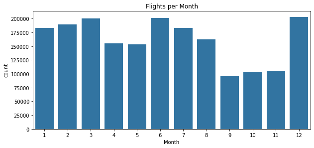

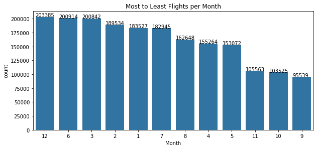

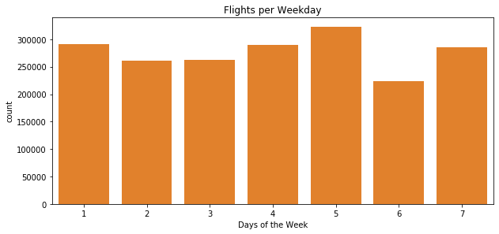

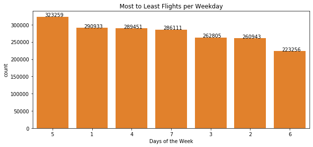

```python
# Countplot of flights per month

plt.figure(figsize = (10,20))
plt.subplot(4, 1, 1)
base_color = sb.color_palette()[0]
sb.countplot(data = flights, x = 'Month', color = base_color)
plt.title('Flights per Month');

# Countplot of flights per month in descending order

plt.figure(figsize = (10,20))
plt.subplot(4, 1, 2)
base_color = sb.color_palette()[0]
month_order = flights['Month'].value_counts().index
ax = sb.countplot(data = flights, x = 'Month', color = base_color, order = month_order)
plt.title('Most to Least Flights per Month')

#annotate bars

for p in ax.patches:
        ax.annotate('{}'.format(p.get_height()), (p.get_x(), p.get_height()+200));

# Counplot of how many flights per day of week

plt.figure(figsize = (10,20))
plt.subplot(4, 1, 3)
color = sb.color_palette()[1]
sb.countplot(data = flights, x = 'DayOfWeek', color = color)
plt.title('Flights per Weekday')
plt.xlabel('Days of the Week');

# Flights per day of week in descending order
plt.figure(figsize = (10,20))
plt.subplot(4, 1, 4)
color = sb.color_palette()[1]
day_order = flights['DayOfWeek'].value_counts().index
ax = sb.countplot(data = flights, x = 'DayOfWeek', color = color, order = day_order)
plt.title('Most to Least Flights per Weekday')
plt.xlabel('Days of the Week')

# annotate bars
for p in ax.patches:
    ax.annotate('{}'.format(p.get_height()), (p.get_x()+0.2, p.get_height()+150));
```

From the simple counplots above, we see that December has the most flights out of the year and Friday sees the most flights out of the week. These results could have been predicted as December is a holiday month where a lot of workers and children/students have a break and many can travel, or many work away from home and go back for the holiday season. Friday is the busiest time of the week as well which can be for similar reasons, as an average Monday-Friday worker would have the weekend off to fly without missing too much work. These are of course all assumptions.

Next to continue on with time, we will see at which hour most flights depart. This might be trickier to sense make because there are other factors that can affect what time a flight departs, and with so many flights from all major airlines, we might not see a trend.

```python
# plt.figure(figsize = (10,10))
# sb.countplot(data = flights, x = 'DepTime', color = 'pink')
# plt.title('Flights by Departure Time')
# plt.xlabel('Departure Time (hour)');
```

```python
# There is missing data
flights[flights['DepTime'] == '']

flights = flights.query('DepTime != ""')

# Test

flights.DepTime.value_counts()
```

```
17    154960
19    153079
18    149753
16    144169
15    142197
14    132178
13    130738
20    130027
12    119208
11    115842
21    111840
10    101913
9      86091
8      68550
22     64136
7      50356
6      33265
23     27382
1       4303
5       2232
2       1199
3        389
24       321
4        204
Name: DepTime, dtype: int64
```

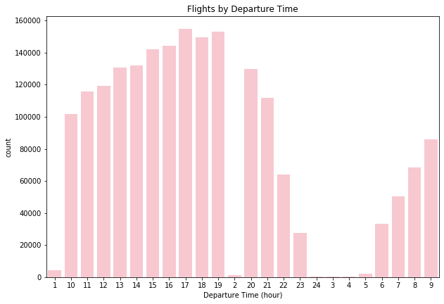

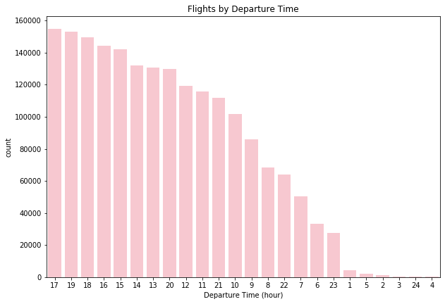

```python
# Replot

plt.figure(figsize = (10,15))
plt.subplot(2, 1, 1)
sb.countplot(data = flights, x = 'DepTime', color = 'pink')
plt.title('Flights by Departure Time')
plt.xlabel('Departure Time (hour)');

# Plot of descending order

plt.figure(figsize = (10,15))
plt.subplot(2, 1, 2)
time_order = flights['DepTime'].value_counts().index
sb.countplot(data = flights, x = 'DepTime', color = 'pink', order = time_order)
plt.title('Flights by Departure Time')
plt.xlabel('Departure Time (hour)');
```

From the departure time countplot above, we see that most flights leave the airport at 17hrs (5:00pm), and the least flights leave at 1:00am, 5:00am, 2:00am, 3:00am, 12:00am, and 4:00am. The least amount of flights left over night, again does not ring any alarms as I would assume most travellers do not prefer overnight flights.

Now that we have a general idea of when flights leave and how often throughout the year, let us take a look at the number of cancelled flights.

```python
cancelled = flights['Cancelled'].mean()
not_cancelled = 1-cancelled

print(cancelled)
print(not_cancelled)
```

```
0.0003253076911884228
0.9996746923088116
```

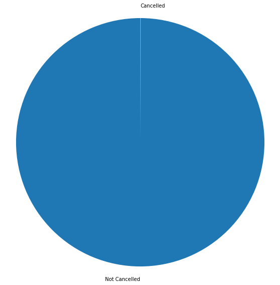

```python
# A Pie Chart may give us a clear view as the variable "Cancelled" is binomial

cancelled_flights = flights['Cancelled'].value_counts()

plt.figure(figsize = (10,10))
cancelled_labels = 'Not Cancelled', 'Cancelled'
plt.pie(cancelled_flights, labels = cancelled_labels, startangle = 90)
plt.axis('square');
```

Pie chart difficult to see as there are only 0.03% of flights out of the year were cancelled. Univariate exploration might not be useful for "Cancelled" at this time, but we will revist when looking at bi or multivariate. Instead, let us plot the reasons for cancellation/ delays (CarrierDelay, WeatherDelay, NASDelay, SecurityDelay, LateAircraftDelay).

We know that Arrival Delay is the sum of all reasons for delay (Carrier, Weather, NAS, Security, Late Aircraft) so we can see a plot of Arrival Delay in minutes.

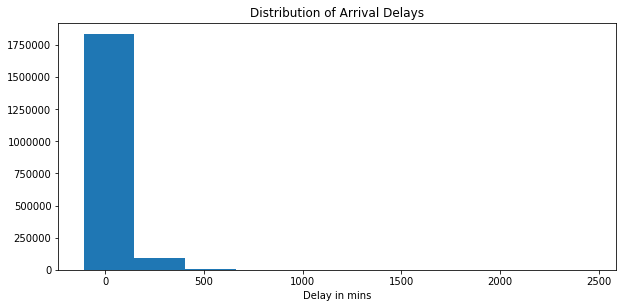

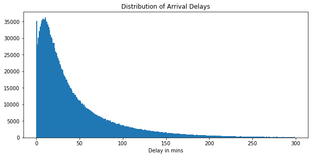

```python
# Histogram of Arrival Delay

plt.figure(figsize = (10,10))
plt.subplot(2, 1, 1)
plt.hist(data = flights, x = 'ArrDelay')
plt.title('Distribution of Arrival Delays')
plt.xlabel('Delay in mins');

# Try a small bin size and bin edges to avoid huge outliers

plt.figure(figsize = (10,10))
plt.subplot(2, 1, 2)
bins = np.arange(0, 300, 1)
plt.hist(data = flights, x = 'ArrDelay', bins = bins)
plt.title('Distribution of Arrival Delays')
plt.xlabel('Delay in mins');
```

When we plotted the histogram without setting any bins or limits, we see only 2 distinct blocks, one from approx. -70mins to 100mins, a second at 100mins to approx. 400mins and a very small one at 400mins to 700mins. To avoid some outliers, I decided to plot a second histogram on a smaller bin size and bin edges from 0-300. We see a large right skewed plot with most delays in 0-25min range.

Let's take a look at the outliers of this plot. First we'll see > 300 mins.

```python
# Arrival Delay of > 300 mins

print(len(flights[flights['ArrDelay'] > 300]))

# > 500 mins

print(len(flights[flights['ArrDelay'] > 500]))

# > 1000 mins

print(len(flights[flights['ArrDelay'] > 1000]))

# > 1500 mins

print(len(flights[flights['ArrDelay'] > 1500]))

# > 2000 mins

print(len(flights[flights['ArrDelay'] > 2000]))
```

```
10104
1510
185
8
2
```

```python
flights[flights['ArrDelay'] > 2000]
```

|  | Year | Month | DayofMonth | DayOfWeek | DepTime | ArrTime | UniqueCarrier | FlightNum | ActualElapsedTime | AirTime | ArrDelay | DepDelay | Origin | Dest | Distance | Cancelled | CancellationCode | Diverted | CarrierDelay | WeatherDelay | NASDelay | SecurityDelay | LateAircraftDelay |
| --- | --- | --- | --- | --- | --- | --- | --- | --- | --- | --- | --- | --- | --- | --- | --- | --- | --- | --- | --- | --- | --- | --- | --- |
| 322516 | 2008 | 2 | 3 | 7 | 11 | 22 | NW | 808 | 459 | 437.0 | 2461 | 2457.0 | HNL | MSP | 3972 | 0 | N | 0 | 1455 | 0 | 4 | 0 | 1002 |
| 686014 | 2008 | 4 | 10 | 4 | 7 | 8 | NW | 1699 | 154 | 132.0 | 2453 | 2467.0 | CLT | MSP | 930 | 0 | N | 0 | 2436 | 0 | 0 | 0 | 17 |

Lastly, we can see which airline carrier had the most US domestic flights in 2008.

```python
flights.UniqueCarrier.value_counts()
```

```
WN    376720
AA    190484
MQ    141763
UA    140326
OO    132099
DL    113369
XE    103378
CO     99218
US     96821
EV     81620
NW     78717
FL     70489
YV     66355
B6     53885
OH     52494
9E     51752
AS     38870
F9     27755
HA      7471
AQ       746
Name: UniqueCarrier, dtype: int64
```

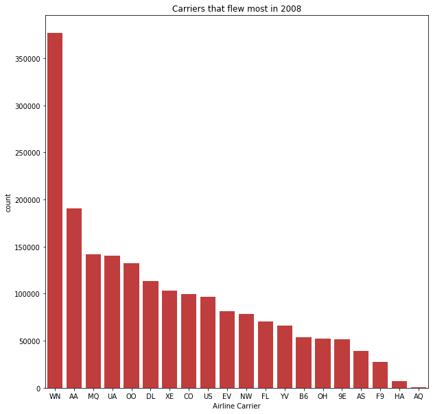

```python
plt.figure(figsize = (10, 10))
order = flights['UniqueCarrier'].value_counts().index
sb.countplot(data = flights, x = 'UniqueCarrier', color = sb.color_palette()[3], order = order)
plt.title('Carriers that flew most in 2008')
plt.xlabel('Airline Carrier');
```

```python
carrier_order = ['WN: Southwest Airlines', 'AA: American Airlines', 'MQ: American Eagle Airlines', 'UA: United Airlines',
       'OO: Skywest Airlines','DL: Delta Airlines','XE: ExpressJet','CO: Continental Airlines','US: US Airways',
       'EV: Atlantic Southeast Airlines', 'NW: Northwest Airlines','FL: AirTran Airways','YV: Mesa Airlines',
       'B6: JetBlue Airways','OH: Comair','9E: Pinnacle Airlines','AS: Alaska Airlines','F9: Frontier Airlines',
       'HA: Hawaiian Airlines','AQ: Aloha Airlines']
```

The Bureau of Transporation Statistics gives a list of all the unique carrier codes. We see that Southwest Airlines had the most flights out of the year, almost double American Airlines who flew out the second most. The two airlines dedicated to the state of Hawaii, Hawaiian Airlines and Aloha Airlines were second to least and least flights flown for the 2008 year.

### Of the features you investigated, were there any unusual distributions? Did you perform any operations on the data to tidy, adjust, or change the form of the data? If so, why did you do this?

The only feature that I investigated that caused adjustment was the last histogram of all of the arrival delays. Most delays experienced were only 0-25mins, but many were far longer up to 1.5 days. This called for a replot of smaller bin edges so we could see where most delays occured.

## Bivariate Exploration

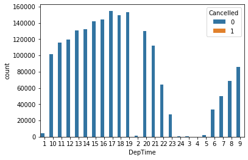

```python
# sb.countplot(data = flights, x = 'Month', hue = 'Cancelled');

# sb.countplot(data = flights, x = 'DayOfWeek', hue = 'Cancelled');

sb.countplot(data = flights, x = 'DepTime', hue = 'Cancelled');
```

Due to the extremely low count of cancelled flights vs non cancelled flights, using this variable does not provide any meaningful insight for exploration. Let's instead use the types of delays to see if we can get a more interesting result.

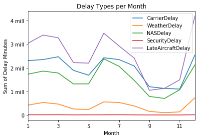

```python
# Filter out the month and delay columns into a new data frame

flights_delay = flights.filter(['Month', 'CarrierDelay', 'WeatherDelay', 'NASDelay', 'SecurityDelay', 'LateAircraftDelay'], axis = 1)

# Groupby month and get sums of delays, plot

flights_delay = flights_delay.groupby('Month')['Month', 'CarrierDelay', 'WeatherDelay', 'NASDelay',
                                               'SecurityDelay', 'LateAircraftDelay'].sum().plot()
flights_delay.legend(loc = 0)
flights_delay.set_title('Delay Types per Month')
flights_delay.set_xlabel('Month')
flights_delay.set_ylabel('Sum of Delay Minutes')
yticks = [0, 1000000, 2000000, 3000000, 4000000]
flights_delay.set_yticks(yticks)
yticklabels = ['0', '1 mill', '2 mill', '3 mill', '4 mill']
flights_delay.set_yticklabels(yticklabels)
plt.show();
```

Our plot above shows that Late Aircraft and Carrier Delays were the two types with the longest delays. I would argue there are 3 spikes, one in March, another in June and another in December. This is probably due to the influx of flights that happen during those three months as well (Flights per Month plot in Part 1).

Carrier and Late Aircraft Delay are both related to the airlines, so next we will see the relationship between unique airline carrier and these two types of delays.

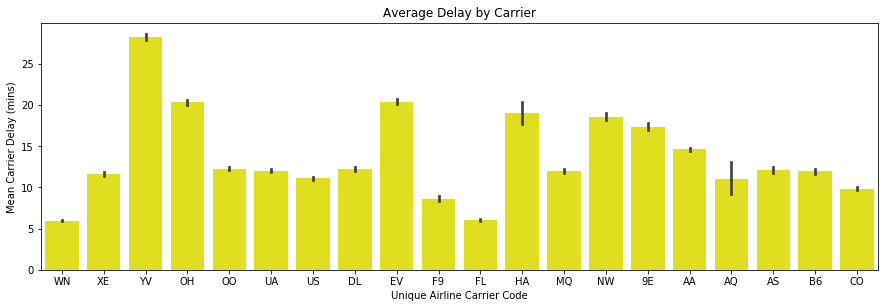

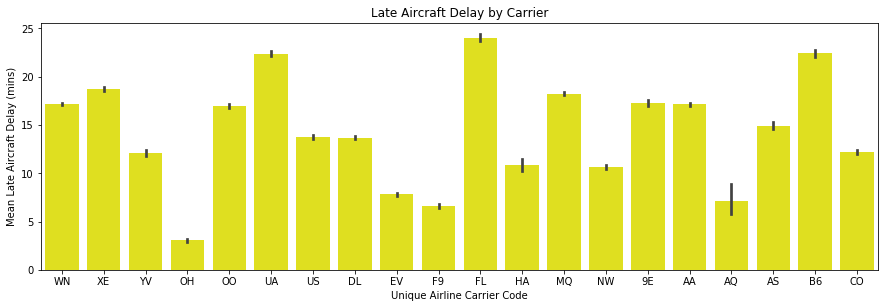

```python
# Carrier Delay and Unique Carrier barplot

plt.figure(figsize = (15, 10))
plt.subplot(2, 1, 1)
sb.barplot(data = flights, x = 'UniqueCarrier', y = 'CarrierDelay', color = 'yellow')
plt.title('Average Delay by Carrier')
plt.xlabel('Unique Airline Carrier Code')
plt.ylabel('Mean Carrier Delay (mins)');

# Late Aircraft Delay and Unique Carrier barplot

plt.figure(figsize = (15, 10))
plt.subplot(2, 1, 2)
sb.barplot(data = flights, x = 'UniqueCarrier', y = 'LateAircraftDelay', color = 'yellow')
plt.title('Late Aircraft Delay by Carrier')
plt.xlabel('Unique Airline Carrier Code')
plt.ylabel('Mean Late Aircraft Delay (mins)');
```

```python
print(carrier_order)
print(flights.groupby('UniqueCarrier')['CarrierDelay'].mean().sort_values(ascending=False))
print(flights.groupby('UniqueCarrier')['LateAircraftDelay'].mean().sort_values(ascending=False))
```

```
['WN: Southwest Airlines', 'AA: American Airlines', 'MQ: American Eagle Airlines', 'UA: United Airlines', 'OO: Skywest Airlines', 'DL: Delta Airlines', 'XE: ExpressJet', 'CO: Continental Airlines', 'US: US Airways', 'EV: Atlantic Southeast Airlines', 'NW: Northwest Airlines', 'FL: AirTran Airways', …
UniqueCarrier
YV    28.162384
EV    20.392355
OH    20.290928
HA    19.018739
NW    18.570931
9E    17.349745
AA    14.607552
OO    12.256497
DL    12.213321
AS    12.145022
UA    12.023324
B6    11.971254
MQ    11.954586
XE    11.597303
US    11.077142
AQ    10.991957
CO     9.821061
F9     8.625509
FL     6.025124
WN     5.954651
Name: CarrierDelay, dtype: float64
UniqueCarrier
FL    24.007363
B6    22.446618
UA    22.380129
XE    18.732138
MQ    18.231344
9E    17.311428
WN    17.143903
AA    17.131313
OO    16.984285
AS    14.896578
US    13.747844
DL    13.698489
CO    12.227428
YV    12.105267
HA    10.837907
NW    10.679294
EV     7.830850
AQ     7.171582
F9     6.607782
OH     3.047377
Name: LateAircraftDelay, dtype: float64
```

The barplots above show the Carrier Delay and Late Aircraft Delay types by each Unique Carrier. YV, Mesa Airlines had an average of 28.16 minutes of carrier delays. EV, Atlantic Southeast Airlines had 20.39 mins and OH, Comair had 20.29 minutes on average of carrier delays. FL, AirTran Airways had the highest average late aircraft delays, B6, JetBlue Airways had the second highest average at 22.44 minutes and UA, United Airlines had 22.38 minutes to round out the third highest on average late aircraft delays.

Southwest Airlines had the shortest amount of average carrier delays at 5.95 minutes, but 17.14 minutes of late aircraft delays. Frontier Airlines had on average the shortest amount of delays for carrier and late aircraft at 8.6 minutes and 6.6 minutes. Comair had on average the shortest amount of late aircraft delays at 3.04 minutes, but fairly high carrier delays as stated above.

### Talk about some of the relationships you observed in this part of the investigation. How did the feature(s) of interest vary with other features in the dataset?

First we tried to show a clustered bar chart of all the months and the cancelled flights. This seemed to be a dead end as the amount of cancelled flights were so low compared to non cancelled. Next we tried to see if day of the week or time showed anything different but we were also at a dead end.

### Did you observe any interesting relationships between the other features (not the main feature(s) of interest)?

Switching directions we took a look at and plotted the relationships of the delays, types of delays and by how much. Grouping by month, we saw that March, June and December had the most amount of delays, which would make sense as there are more flights during those times. After finding out the carrier delays and delays due to a late aircraft were the two that had the most, we plotted the relationship of these delays with the unique airline carriers. The highest average delays were 28.16 and 24 minutes for carrier and late aircraft respectively. Looking back at the "Count of Arrival Delays" plot in part 1, we concluded that most arrival delays were between 0-25 minutes, so this relationship that we plotted in part 2 and seeing the highest average carrier and late aircraft delays being average about 26 minutes is be associated.

## Multivariate Exploration

We will first plot a correlated heat map of our data set to get some high level information prior to further exploration.

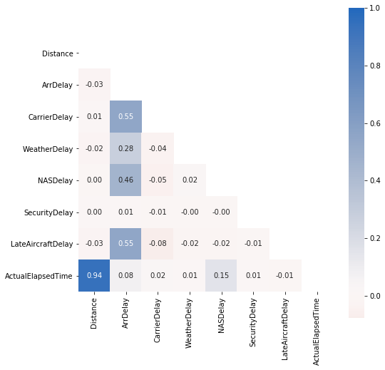

```python
corr_col = ['Distance', 'ArrDelay', 'CarrierDelay', 'WeatherDelay', 'NASDelay',
            'SecurityDelay', 'LateAircraftDelay', 'ActualElapsedTime' ]

corr = flights[corr_col].corr()

plt.figure(figsize = (8,8))
mask = np.zeros_like(corr)
mask[np.triu_indices_from(mask)] = True      #masking the upper half of triangle to cut redundancy
sb.heatmap(corr, annot = True, fmt = '0.2f', cmap = 'vlag_r',
           center = 0, square = True, mask = mask)
plt.ylim(len(corr), -0.1);
```

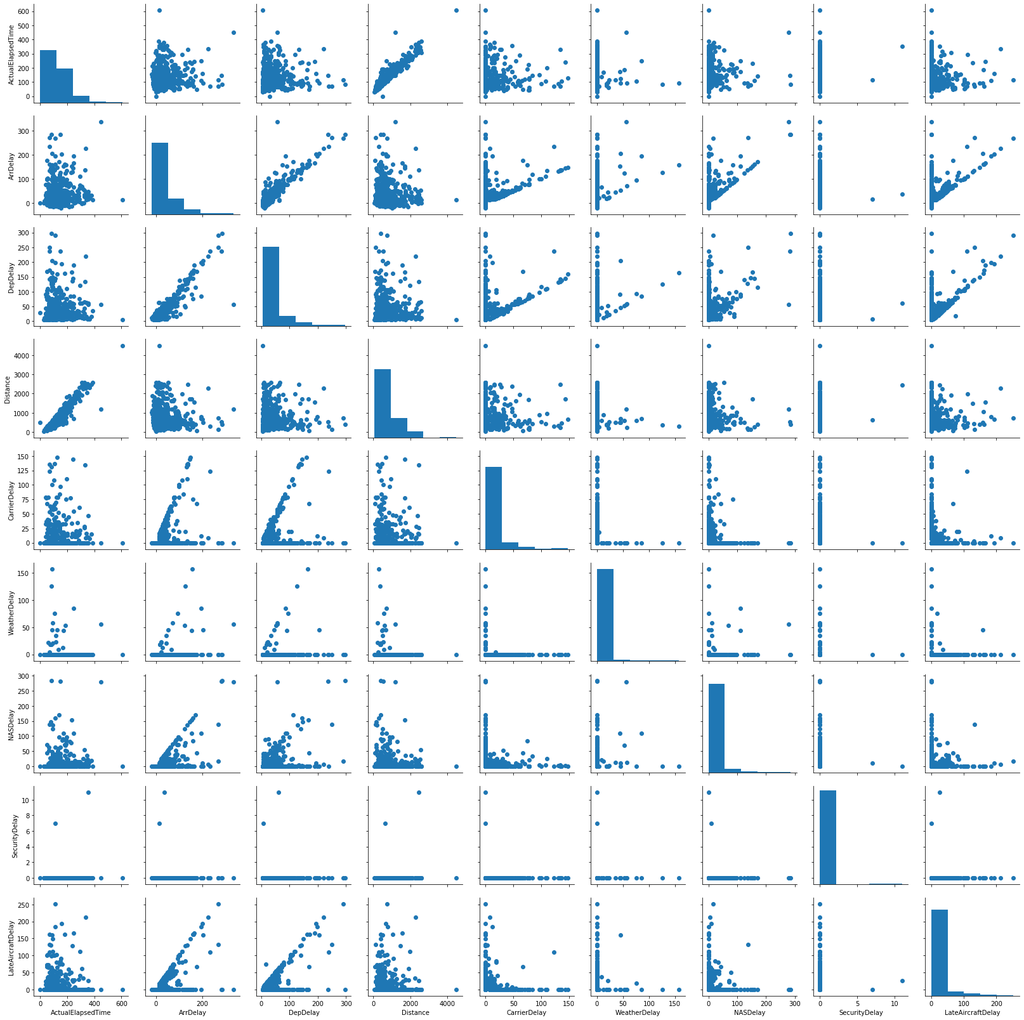

```python
var = ['ActualElapsedTime', 'ArrDelay', 'DepDelay', 'Distance', 'CarrierDelay',
       'WeatherDelay', 'NASDelay', 'SecurityDelay', 'LateAircraftDelay']

# Using a sample of 500 to render plots faster

sample = np.random.choice(flights.shape[0], 500, replace = False)
flights_samp = flights.loc[sample,:]

g = sb.PairGrid(data = flights_samp, vars = var)
g.map_diag(plt.hist, bins = 5)
g.map_offdiag(plt.scatter);
```

As expected, actual elapsed time and distance are correlated and arrival and departure delays are correlated. As seen in the heat map prior, arrival and departure delays are positively correlated with the different types of delays.

Let us hone in on all the types of delays and arrival delay as we might be able to see a highly correlated result. Security Delay will be ommited as a high correlation was not reflected in the Pair Grid above and will increase data to ink ratio, making the plot easier to read.

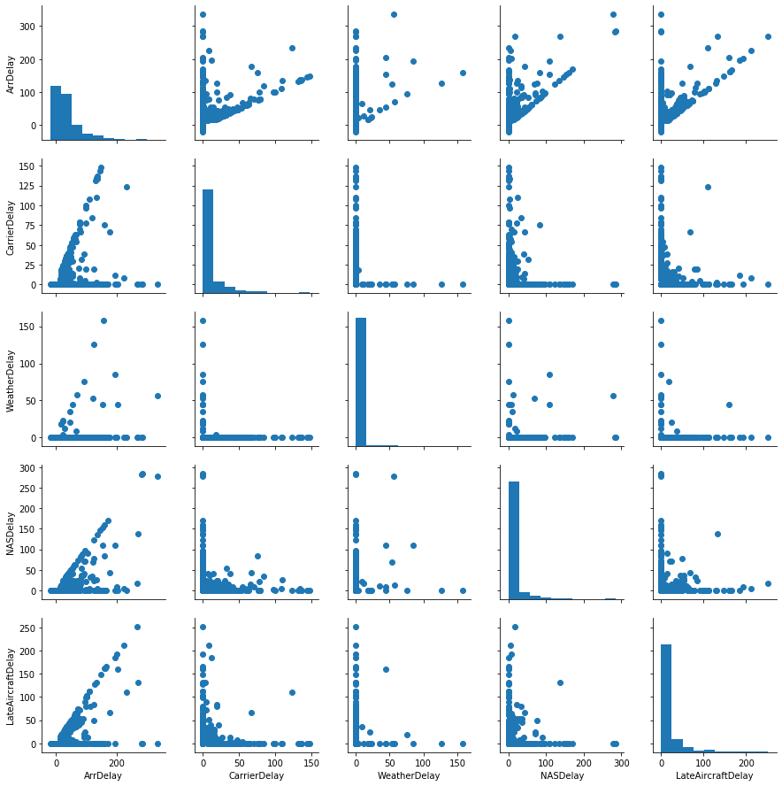

```python
# Numeric variables of interest

variables = ['ArrDelay', 'CarrierDelay', 'WeatherDelay', 'NASDelay', 'LateAircraftDelay']

# Use same sample size from above to render plots faster

g = sb.PairGrid(data = flights_samp, vars = variables)
g.map_diag(plt.hist)
g.map_offdiag(plt.scatter);
```

This PairGrid of Carrier, Weather, NAS, Late Aircraft and Arrival delay show again the correlation between these delays with arrival delay independently. I think it would be safe to say that each type of flight delay is not correlated with each other- hence why they are separate variables/columns/types.

I would like to explore the relationship between each type of delay (minus security), arrival and departure delays, we will use a scatter plot for this relationship.

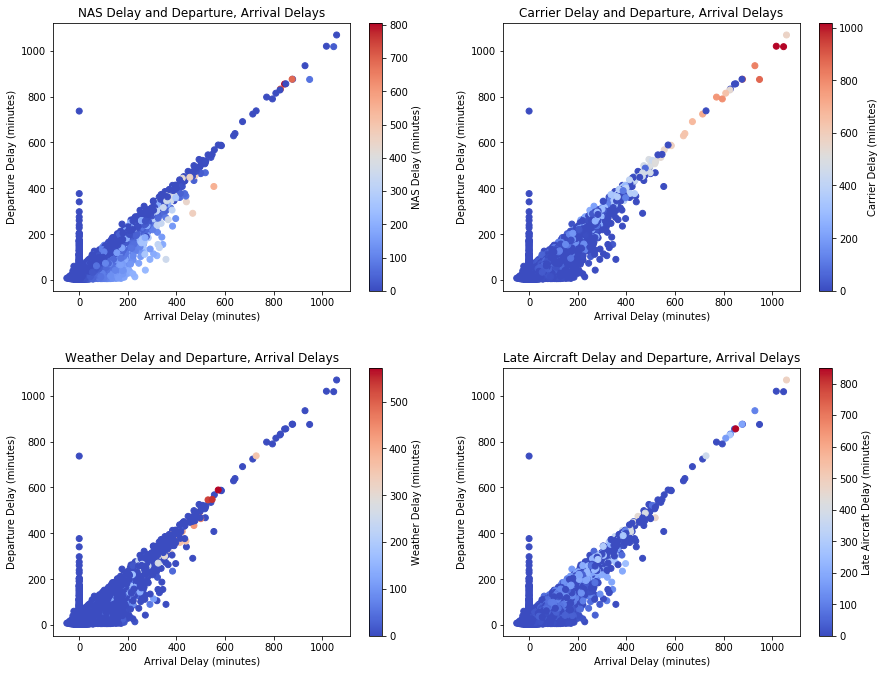

```python
# Using sample of 50,000 to render a plot faster

sample2 = np.random.choice(flights.shape[0], 50000, replace = False)
samp = flights.loc[sample2,:]

plt.figure(figsize = (13, 10))

# NAS Delay

plt.subplot(2,2,1)
plt.scatter(data = samp, c = 'NASDelay', x = 'ArrDelay', y = 'DepDelay', cmap = 'coolwarm')
plt.colorbar(label = 'NAS Delay (minutes)')
plt.xlabel('Arrival Delay (minutes)')
plt.ylabel('Departure Delay (minutes)')
plt.title('NAS Delay and Departure, Arrival Delays');

# Carrier Delay

plt.subplot(2,2,2)
plt.scatter(data = samp, c = 'CarrierDelay', x = 'ArrDelay', y = 'DepDelay', cmap = 'coolwarm')
plt.colorbar(label = 'Carrier Delay (minutes)')
plt.xlabel('Arrival Delay (minutes)')
plt.ylabel('Departure Delay (minutes)')
plt.title('Carrier Delay and Departure, Arrival Delays');

# Weather Delay

plt.subplot(2,2,3)
plt.scatter(data = samp, c = 'WeatherDelay', x = 'ArrDelay', y = 'DepDelay', cmap = 'coolwarm')
plt.colorbar(label = 'Weather Delay (minutes)')
plt.xlabel('Arrival Delay (minutes)')
plt.ylabel('Departure Delay (minutes)')
plt.title('Weather Delay and Departure, Arrival Delays');

# Late Aircraft Delay

plt.subplot(2,2,4)
plt.scatter(data = samp, c = 'LateAircraftDelay', x = 'ArrDelay', y = 'DepDelay', cmap = 'coolwarm')
plt.colorbar(label = 'Late Aircraft Delay (minutes)')
plt.xlabel('Arrival Delay (minutes)')
plt.ylabel('Departure Delay (minutes)')
plt.title('Late Aircraft Delay and Departure, Arrival Delays');

plt.tight_layout(pad = 3)
```

These 4 scatter plots show the highly correlated relationship between the arrival and departure time delays with a color bar encoding the different types of flight delays. You can see that there are quite long carrier delays (minutes) and some outliers as well.

### Talk about some of the relationships you observed in this part of the investigation. Were there features that strengthened each other in terms of looking at your feature(s) of interest?

In this part of the investigation, I wanted to focus on the types of delays and how their relationship was between each other and of course between arrival and departure delays. I was able to explore the different types of delays with respect to arrival and departure delays but was not successful with seeing the relationship between each type of delay.